# Test of two proportions

## Comparing two binary outcomes

- Is there a difference in the proportion of deaths between male passengers and female passengers on the Titanic?
- Is there difference in the proportion of patients finishing the full three doses of HPV vaccine between Black women and White women?
- Does using a ng tube for feeding in pre-term infants increase the probability of successful breast feeding at six months?

## Other comparisons involving a binary outcome

- Is there are difference in the proportion of deaths between first class, second class, and third class passengers?
- Does age influence the proportion of women finishing the full three doses of HPV vaccine?
- Controlling for the mother’s age, does using a ng tube for feeding in pre-term infants increase the probability of successful breast feeding at six months?

## Titanic data, 1 of 3

```
data_dictionary: titanic.txt
```

```
description: Mortality among passengers of the Titanic
```

## Titanic data, 2 of 3

```
Name:
  label: Passenger name
PClass:
  label: Passenger class
  scale: ordinal
  values: 1st, 2nd, 3rd
Age:
  unit: years
  scale: positive discrete
  missing: NA
```

## Titanic data, 3 of 3

```
Sex:
  scale: binary
  values: female, male
Survived:
  scale: binary
  values:
    '1': yes
    '0': no
```

## Data layout, 1 of 2

[figure not shown]

## Data layout, 2 of 2

[figure not shown]

## Confidence interval and test of hypothesis

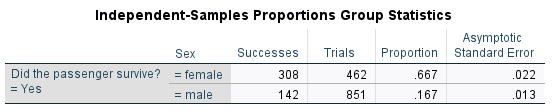

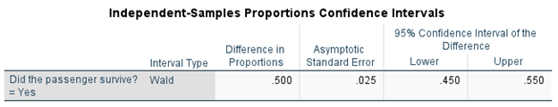

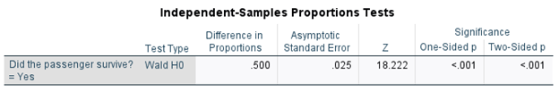